# Taking uncertainty seriously A Bayesian approach to word embedding bias estimation

Alicja Dobrzeniecka & Rafal Urbaniak (LoPSE research group, University of Gdansk, Vrije Universiteit Amsterdam)

Boston, April Fools’ Day

# Presentation plan

- Bias in word embeddings
- WEAT and MAC methods
- Methodological problems
- Limitations of pre-averaging in bias detection methods
- Accounting for uncertainty with Bayesian approach

# Word2vec

### Question

How to sensibly represent words with numbers?

### One-hot encoding

Well, you could use 30k binary vectors with a slot for each lexical unit

but this would be inefficient and wouldn’t capture any relations between words.

# Word2vec

Illustration: M. Mitchell

# Word2vec

Illustration: M. Mitchell

# Word2vec

# Word2vec

### Distributional semantics

Illustration: M. Mitchell

# Word2vec

### Google and Mikolov

, 2013

Let’s train a neural network and use vectors of weights!

Illustration: M. Mitchell

# Word2vec

### Google and Mikolov

, 2013

Let’s train a neural network and use vectors of weights!

Illustration: M. Mitchell

# Word2vec

| word | 1 | 2 | 3 | 4 | … |
| --- | --- | --- | --- | --- | --- |
| woman | 0.456 | 0.267 | 0.675 | 0.131 | … |
| man | 0.451 | 0.897 | 0.472 | 0.088 | … |

### Question

How is this supposed to capture semantic relations?

### General idea

Similarity in vector direction.

# Cosine similarity

# Cosine similarity

# Cosine similarity

# Cosine similarity

# Cosine similarity & distance

$$\begin{align} \tag{Sim}
\mathsf{cosineSimilarity}(A,B) & = \frac{A \cdot B}{\lVert A \rVert \,\lVert B \rVert}
\\
\tag{Distance}
\mathsf{cosineDistance}(A,B) & = 1 - \mathsf{cosineSimilarity}(A,B)
\end{align}$$

- Naive interpretation: proximity corresponds to semantic similarity
- Geometric interpretation: direction $\mathsf{cos} \in (-1,1)$
  - $1$: maximally smilar
  - $-1$: opposites
  - $0$: dissimilar
- $\mathsf{cosineDistance}\in (0, 2)$

# Cosine similarity & distance

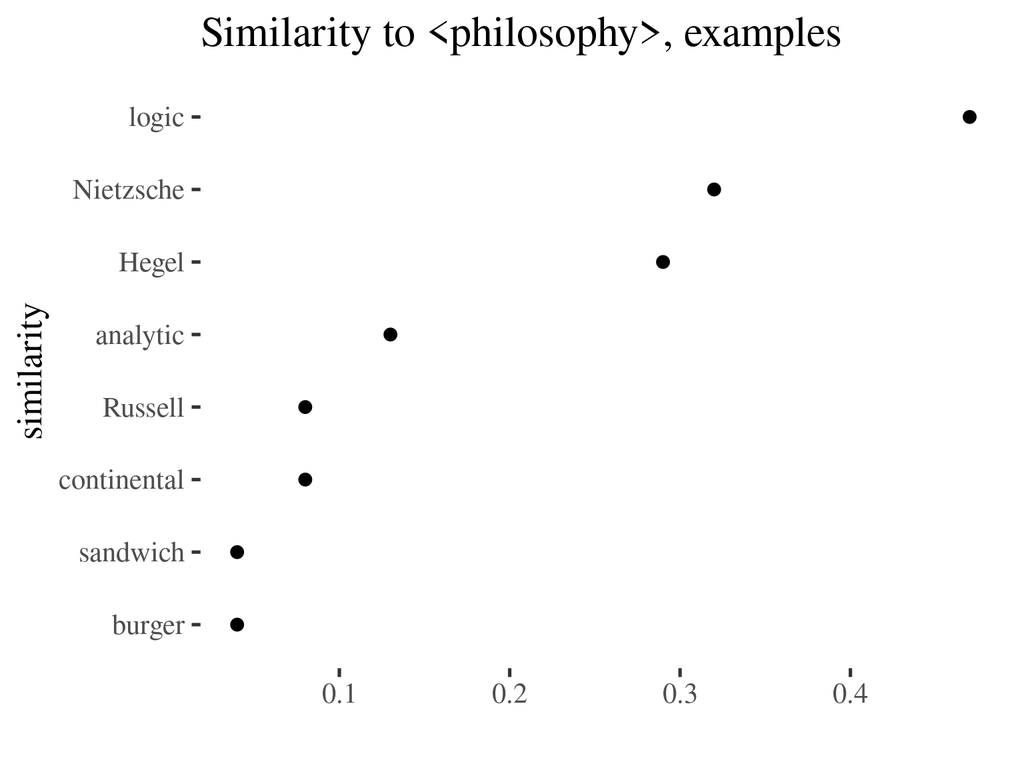

### The only “jobs” in top-tens

- Man: robber (.55)
- Woman: policewoman (.6)

# Cosine-based measures of bias

### The worry

Word embeddings can learn implicit harmful biases

### The basic intuition

Stereotypically connected words are cosine-close

# Cosine-based measures of bias

### A visual example

- “feminine” occupations: “homemaker,” “nurse,” “receptionist,” “librarian,” etc.
- “masculine” occupations: “maestro,” “captain,” “architect,” “boss,” etc.

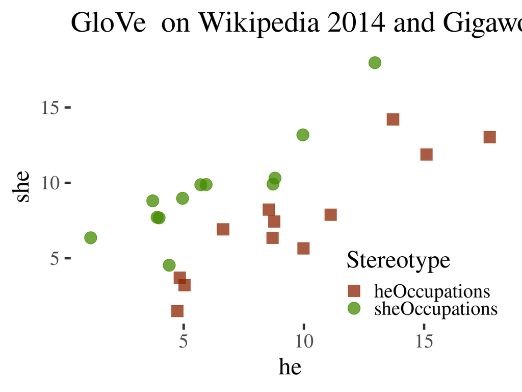

# Cosine-based measures of bias

### Example: Word Embedding Association Test (WEAT)

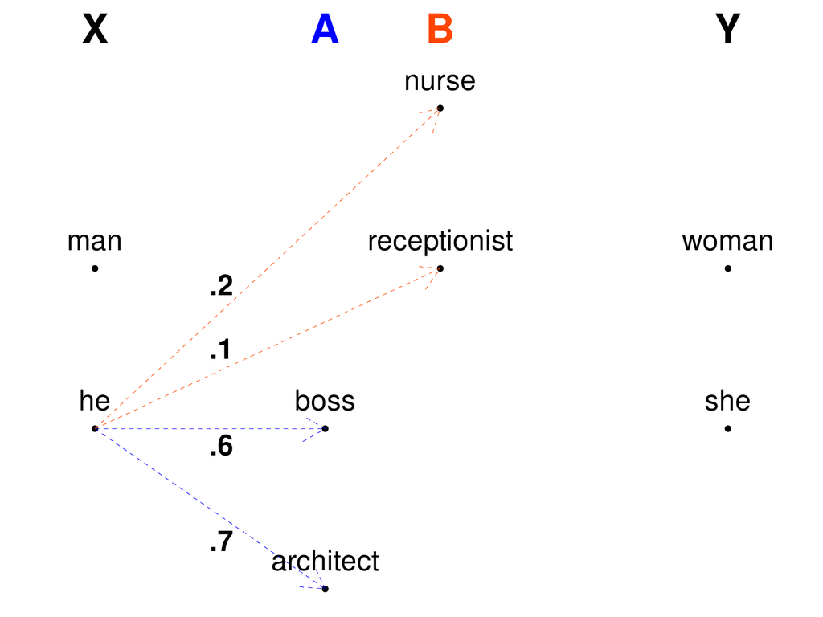

- $s_1 = s(he,A,B) = \frac{.6+.7}{2} - \frac{.2+.1}{2} = .65-.15= .5$
- $s_2 = s(man,A,B) = .3$, $s_3 = s(woman,A,B) = -.6, s_4 = s(she, A, B) = -.3$

$$\begin{align*}
\mathsf{WEAT}(A,B) & = \frac{\nicefrac{(s_1+s_2)}{2} - \nicefrac{(s_3+s_4)}{2}}{sd(\{s_1,s_2,s_3,s_4\})} \approx 1.93
\end{align*}$$

# Cosine-based measures of bias

### Example: Word Embedding Association Test (WEAT)

$$\begin{align*}
s(t,A,B) & = \frac{\sum_{a\in A}f(t,a)}{\vert A\vert} - \frac{\sum_{b\in B}f(t,b)}{\vert B\vert}
\\
WEAT(A,B) & = \frac{
\mu\left(\{s(x,A,B)\}_{x\in X}\right) -\mu\left(\{s(y,A,B)\}_{y\in Y}\right)
}{
\sigma\left(\{s(w,A,B)\}_{w\in X\cup Y}\right)
}
\end{align*}$$

- $t$ is a term, $A, B$ are sets of stereotype attribute words, $X$, $Y$ are protected group words
- For instance, $X$ might be a set of male names, $Y$ a set of female names, $A$ might contain stereotypically male-related career words, and $B$ stereotypically female-related family words
- $s$-values are used as datapoints in statistical significance tests

(Caliskan, Bryson, & Narayanan, 2017) with extensions in (Lauscher & Glavas, 2019) and applications in (Garg, Schiebinger, Jurafsky, & Zou, 2018)

# Cosine-based measures of bias

### Our main target: Mean Average Cosine Similarity (MAC)

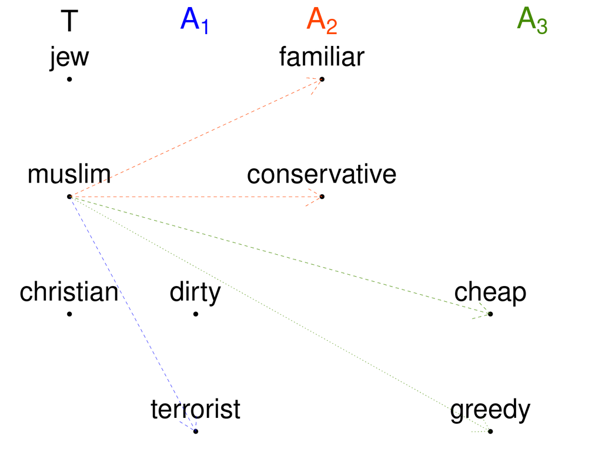

$$\begin{align*}
s_1 & = s(muslim,A_1) = \frac{cos(muslim,dirty)+cos(muslim,terrorist)}{2}\\
s_2 & = s(muslim,A_2) = \frac{cos(muslim,familiar)+cos(muslim,conservative)}{2}\\
& \vdots \end{align*}$$

$$\begin{align*}
MAC(T,A) & = \mathsf{mean}(\{s_i \vert i \in 1, \dots, k\})
\end{align*}$$

# Cosine-based measures of bias

### Our main target: Mean Average Cosine Similarity (MAC)

$$\begin{align*}
S(t_i, A_j) & = \frac{1}{\vert A_j\vert}\sum_{a\in A_j}\mathsf{cos}(t,a) \\
MAC(T,A) & = \frac{1}{\vert T \vert \,\vert A\vert}\sum_{t_i \in T }\sum_{A_j \in A} S(t_i,A_j)
\end{align*}$$

- $T = \{t_1, \dots, t_k\}$ is a class of protected words
- each $A_j\in A$ is a set of attributes stereotypically associated with a protected word
- The t-tests they employ are run on average cosines used to calculate MAC

(Manzini, Lim, Tsvetkov, & Black, 2019)

# Cosine-based measures of bias

### Our main target: Mean Average Cosine Similarity (MAC)

# Cosine-based measures of bias

### General challenges

- Gender-direction: insufficient indicator of bias (Gonen & Goldberg, 2019)
- Use of analogies: unreliable (Nissim, Noord, & Goot, 2020)
- High sensitivity to irrelevant factors (Zhang, Sneyd, & Stevenson, 2020)

# Some methodological problems

### Word list choice is unprincipled

- We run with it for comparison.

### No design considerations to sample size

- Ethayarajh (2020) criticizes WEAT uses Bernstein bounds and argues that we would need a bias specific dataset of size at least 11903 to claim that the system is biased (three times larger than WinoBias).
- We show progress can be made with more sensitive Bayesian methods.

### The form of the definition is suspicious

- Ethayarajh, Duvenaud, & Hirst (2019) show that if there are two target words only WEAT is always maximal in one direction.
- We show the problem runs deeper and stems from pre-averaging, and we statistically gauge the uncertainty that arises from raw sample sizes.

# Some methodological problems

### No word class distinction and no control group

We make the subclasses clear, add human neutral predicates and neutral predicates for control. We used L2-Reddit corpus and GoogleNews (we present the results for Reddit for brevity).

# Some methodological problems

### Our neutral words (examples, full list size = 242)

liquor, pow, ballpark, glitchy, billy, dallas, rip, called, outlooks, viet, floater, rattlesnake, exports, peruvian, recursion, shortfall, corrected, amicable, solutions, diagnostic, patently, flops, approx, percents, lox, catapults, hamburger, engulfed, households, north, snubbed, playtest

### Our human-related words (examples, full list size = 27)

wear, walk, visitor, toy, tissue, throw, talk, speak, sleep, eye, enjoy, blogger, character, candidate, breakfast, supper, dinner, eat, drink, carry, run, cast, ask, awake, ear, nose, lunch

# Some methodological problems

### Outliers and surprisingly dissimilar words

We study those by visualizations and uncertainty estimates.

# Some methodological problems

### Distances for “muslim”

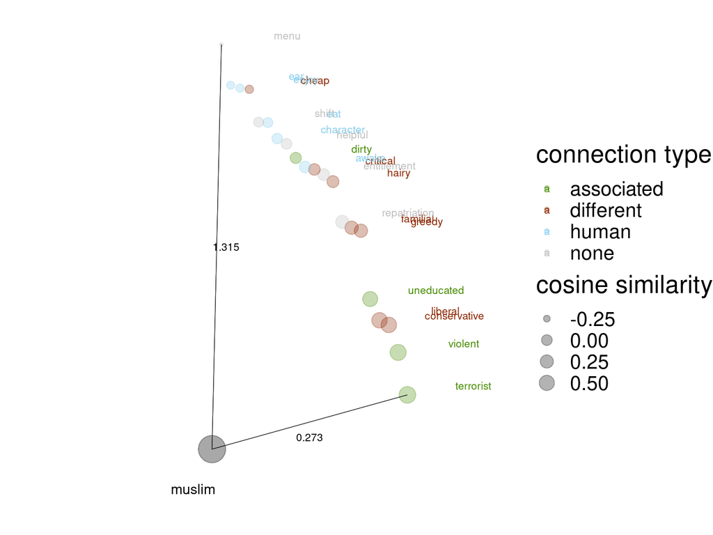

# Some methodological problems

### Distances for “priest”

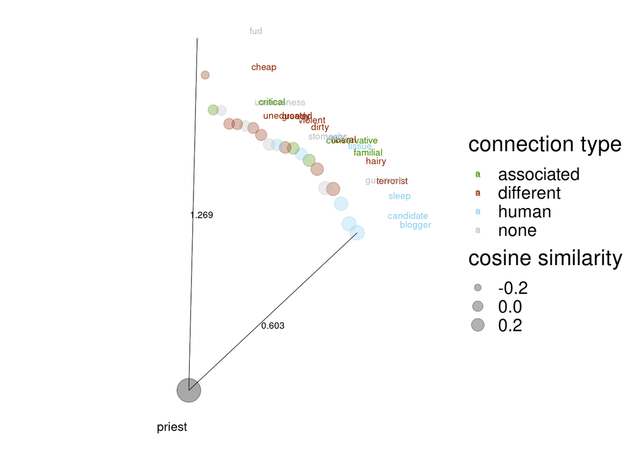

# Some methodological problems

### No principled interpretation

| Category | Biased | Hard Debiased | Diff |  |
| --- | --- | --- | --- | --- |
| Religion | 0.859 | 0.934 | 0,141 |  |
| Race | 0.892 | 0.925 | 0,108 |  |
| Gender | 0.623 | 0.700 | 0,377 |  |

- What values are sufficient for the presence of bias and what differences are sign of real improvement?
- Low $p$-values are not high effect indicators!
- We compare HPDIs.

# Some methodological problems

### No principled interpretation - visualization 1

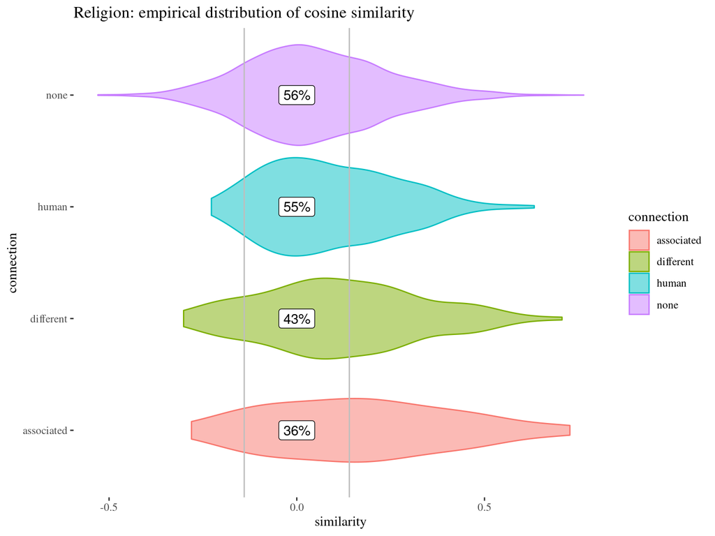

# Some methodological problems

### No principled interpretation - visualization 2

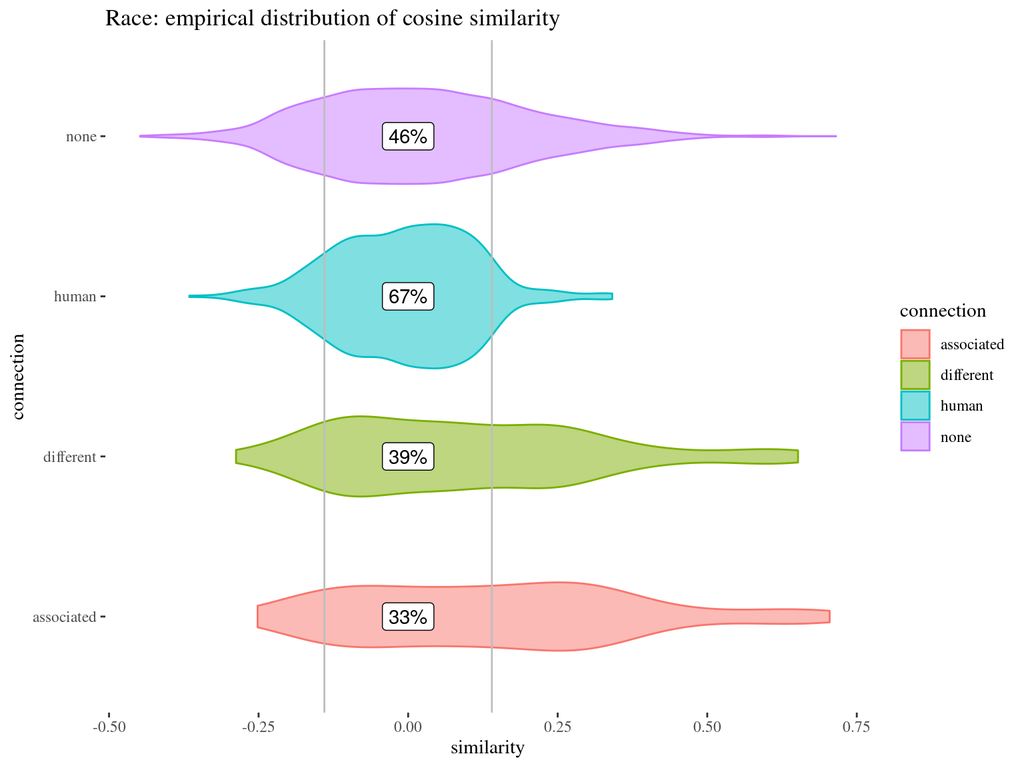

# Some methodological problems

### No principled interpretation - visualization 3

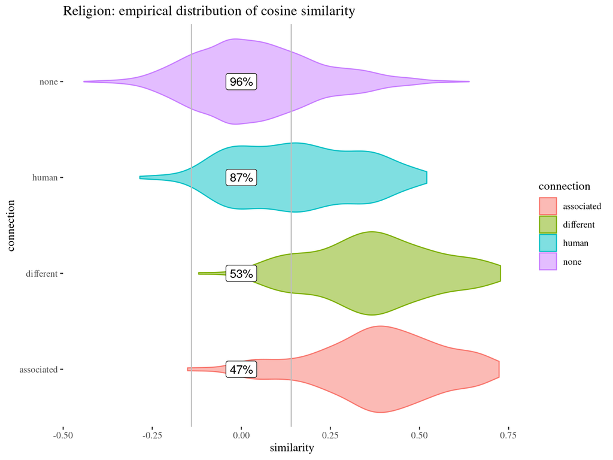

# The problem with pre-averaging

### Key conceptual issues

- It throws away information about sample sizes
- It ignores variation in the raw data, which leads to false confidence

### Our simulations

Suppose all similarities for two classes are randomly drawn from the same distribution, $\mathsf{Normal}(\mu = 0, \sigma = .08)$, you still can get a really high WEAT!

# The problem with pre-averaging

### Simple case: two pws, four terms

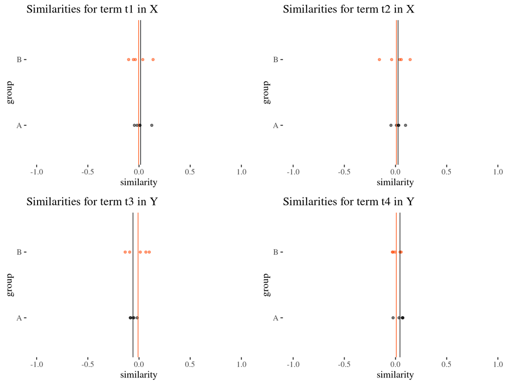

- Raw sd in data is 0.072
- The sd of means is 0.037
- The WEAT score is 1.825
- The largest effect size reported by Caliskan, Bryson, & Narayanan (2017) is 1.81!

# The problem with pre-averaging on realistic set-up

### Simulation with realistic set-up (16 predicates)

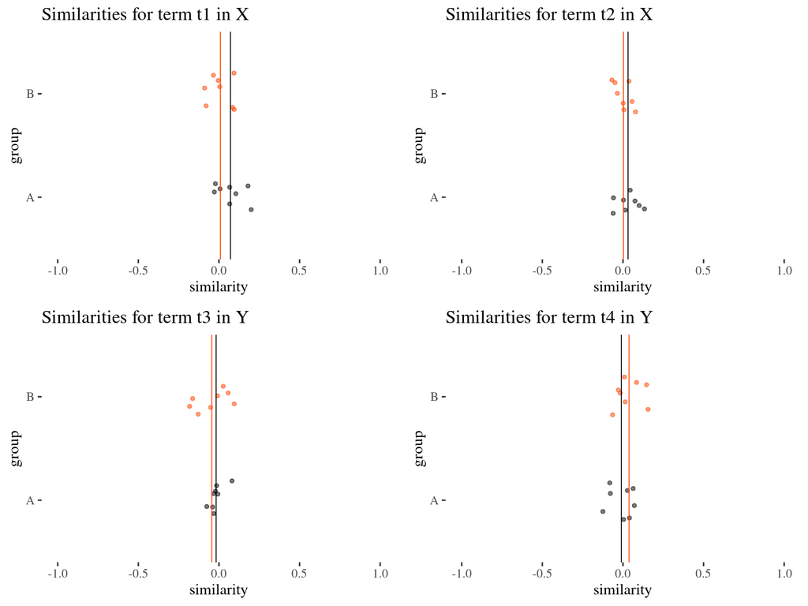

Raw sd: 0.082, sd of means: 0.031, WEAT: 2.337.

# The problem with pre-averaging on realistic set-up

### 10k simulations (same parameters)

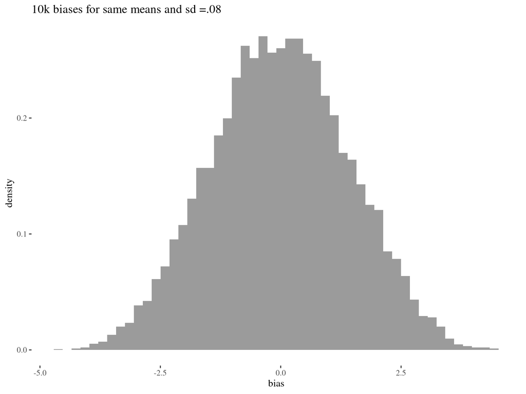

- 95% of the scores are in range -2.763, 2.698
- 21.38% of the absolute values are above 1.81

# The problem with pre-averaging on realistic set-up

### 10k simulations with mean similarity 0.1

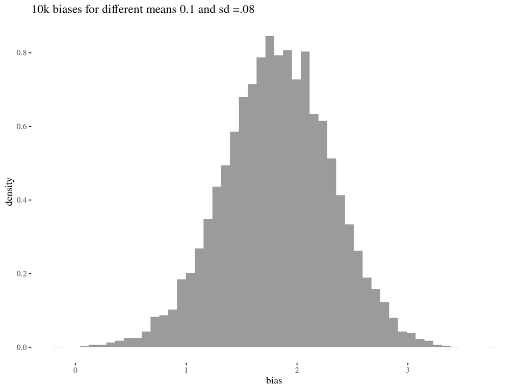

- 95% of the scores are in range 0.851, 2.764
- 51.3% of the absolute values are above 1.81

# The problem with pre-averaging on realistic set-up

### 10k simulations with mean similarity 0.4

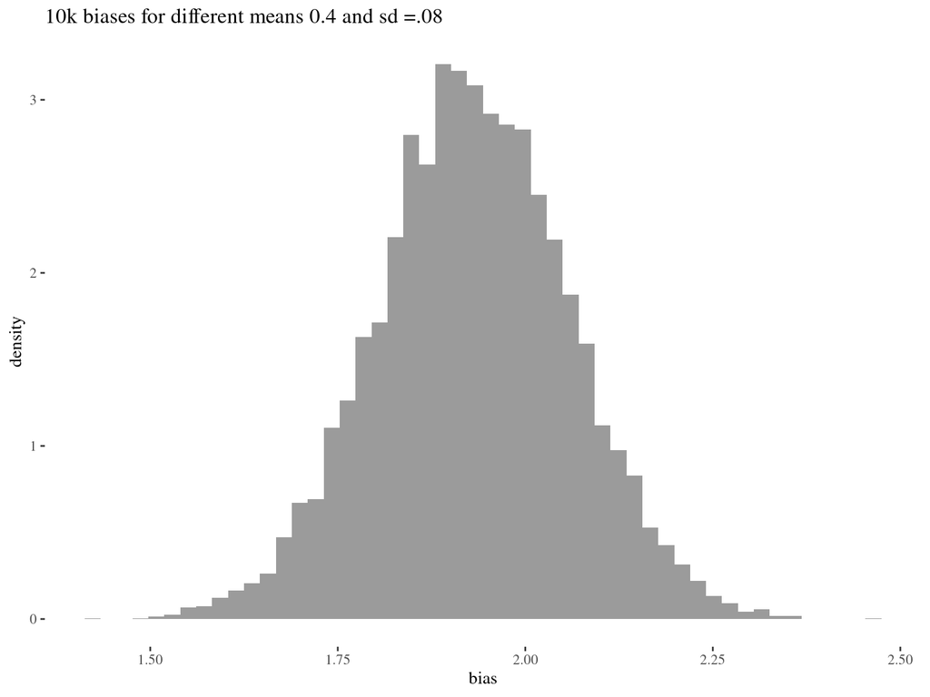

- 95% of the scores are in range 1.679, 2.185
- 82.9% of the absolute values are above 1.81

# Advantages of the Bayesian way

- Direct impact of sample sizes
- Straightforward interpretation in terms of posterior probabilities
- Freedom to choose granularity level
- More honest risk assessment and decision making